# Tugas Pertemuan 3

Fathoni Sabri

2025-09-18

# Library

```r
library(dLagM)
library(dynlm)
library(MLmetrics)
library(lmtest)
library(car)
library(readr)
library(dplyr)
```

# Import Data

```r
dataset <- read.csv("C:/Users/Fathoni Sabri/OneDrive/Documents/Semester 5/MPDW/Repository/Pertemuan 3/NewDelhi_Air_quality.csv")
dataset
```

```
##     X  AQI       CO      datetime        no2       o3      pm10     pm25
## 1   0 30.2 198.6027 2022-10-21:18 0.04685717 55.78995 10.486722 5.637410
## 2   1 28.2 197.6013 2022-10-21:19 0.04645554 54.93164 10.719325 4.618169
## 3   2 26.6 198.6027 2022-10-21:20 0.04685717 54.64554 11.155578 3.520902
## 4   3 25.0 201.9405 2022-10-21:21 0.04819594 55.07469 11.116206 2.225919
## 5   4 26.0 205.2784 2022-10-21:22 0.04886533 55.78995 10.405250 1.979471
## 6   5 26.0 208.6163 2022-10-21:23 0.05020411 56.50520  9.402518 1.792677
## 7   6 26.0 208.6163 2022-10-22:00 0.05020411 55.78995  8.482822 1.752237
## 8   7 24.0 205.2784 2022-10-22:01 0.05020411 52.92892  7.586667 1.858459
## 9   8 23.0 200.2716 2022-10-22:02 0.04685717 50.06790  7.636587 2.208076
## 10  9 24.0 196.9338 2022-10-22:03 0.04417961 51.49841  8.487648 2.476681
## 11 10 25.0 198.6027 2022-10-22:04 0.04284084 53.64418  9.357371 2.585729
## 12 11 26.0 200.2716 2022-10-22:05 0.04049798 55.78995 10.338728 2.390081
## 13 12 27.0 203.6095 2022-10-22:06 0.04016329 59.36623 10.523314 2.086022
## 14 13 29.0 205.2784 2022-10-22:07 0.03882451 62.22725 10.635970 1.937047
```

[output cut: 131 more lines]

```r
str(dataset)
```

```
## 'data.frame':    72 obs. of  12 variables:
##  $ X              : int  0 1 2 3 4 5 6 7 8 9 ...
##  $ AQI            : num  30.2 28.2 26.6 25 26 26 26 24 23 24 ...
##  $ CO             : num  199 198 199 202 205 ...
##  $ datetime       : chr  "2022-10-21:18" "2022-10-21:19" "2022-10-21:20" "2022-10-21:21" ...
##  $ no2            : num  0.0469 0.0465 0.0469 0.0482 0.0489 ...
##  $ o3             : num  55.8 54.9 54.6 55.1 55.8 ...
##  $ pm10           : num  10.5 10.7 11.2 11.1 10.4 ...
##  $ pm25           : num  5.64 4.62 3.52 2.23 1.98 ...
##  $ so2            : num  0.387 0.41 0.402 0.376 0.339 ...
##  $ timestamp_local: chr  "2022-10-21T23:00:00" "2022-10-22T00:00:00" "2022-10-22T01:00:00" "2022-10-22T02:00:00" ...
##  $ timestamp_utc  : chr  "2022-10-21T18:00:00" "2022-10-21T19:00:00" "2022-10-21T20:00:00" "2022-10-21T21:00:00" ...
##  $ ts             : int  1666375200 1666378800 1666382400 1666386000 1666389600 1666393200 1666396800 1666400400 1666404000 1666407600 ...
```

```r
data <- dataset %>% select(-c('X', 'datetime', 'no2', 'o3', 'pm10', 'pm25', 'CO', 'timestamp_local', 'timestamp_utc', 'ts'))
head(data)
```

```
##    AQI       so2
## 1 30.2 0.3874302
## 2 28.2 0.4097819
## 3 26.6 0.4023313
## 4 25.0 0.3762543
## 5 26.0 0.3390014
## 6 26.0 0.3129244
```

Menetapkan AQI sebagai peubah terikat dan SO2 sebagai peubah penjelas.

# Pembagian Data

```r
train<-data[1:64,]
test<-data[65:72,]
```

Pembagian data menggunakan rasio 8:1, dimana train berjumlah 64 amatan dan test berjumlah 8 amatan.

```r
train.ts<-ts(train)
test.ts<-ts(test)
data.ts<-ts(data)
```

# Model Koyck

## Pemodelan

```r
model.koyck <- koyckDlm(x = train$so2, y = train$AQI)
summary(model.koyck)
```

```
##
## Call:
## "Y ~ (Intercept) + Y.1 + X.t"
##
## Residuals:
##     Min      1Q  Median      3Q     Max
## -1.9460 -0.7483  0.0550  0.3637  2.1710
##
## Coefficients:
##             Estimate Std. Error t value Pr(>|t|)
## (Intercept)  3.13363    3.05525   1.026    0.309
## Y.1          0.92777    0.06468  14.345   <2e-16 ***
## X.t         -3.82147    4.23978  -0.901    0.371
## ---
## Signif. codes:  0 '***' 0.001 '**' 0.01 '*' 0.05 '.' 0.1 ' ' 1
##
## Residual standard error: 0.9308 on 60 degrees of freedom
## Multiple R-Squared: 0.903,   Adjusted R-squared: 0.8997
## Wald test: 277.2 on 2 and 60 DF,  p-value: < 2.2e-16
##
## Diagnostic tests:
## NULL
##
##                             alpha      beta       phi
## Geometric coefficients:  43.38674 -3.821472 0.9277746
```

```r
AIC(model.koyck)
```

```
## [1] 174.6803
```

```r
BIC(model.koyck)
```

```
## [1] 183.2529
```

Dari hasil tersebut, didapat bahwa peubah $AQI_{-1}$ memiliki nilai $p-value<0.05$. Hal ini menunjukkan bahwa peubah $AQI_{-1}$ berpengaruh signifikan terhadap $AQI$. Model ini juga memiliki nilai adjusted R-sq sebesar 0.8997. Adapun model keseluruhannya adalah sebagai berikut.

$$\hat{AQI_t}=3.13363-3.82147SO2_t+0.92777AQI_{t-1}$$

## Peramalan dan Akurasi

Berikut adalah hasil peramalan $AQI$ untuk 8 periode kedepan menggunakan model koyck.

```r
fore.koyck <- forecast(model = model.koyck, x=test$so2, h=8)
fore.koyck
```

```
## $forecasts
## [1] 20.12315 20.25164 20.39932 20.56481 20.74681 20.94415 21.14146 21.33876
##
## $call
## forecast.koyckDlm(model = model.koyck, x = test$so2, h = 8)
##
## attr(,"class")
## [1] "forecast.koyckDlm" "dLagM"
```

```r
mape.koyck <- MAPE(fore.koyck$forecasts, test$AQI)
mape.koyck
```

```
## [1] 0.1195151
```

```r
GoF(model.koyck)
```

```
##              n       MAE          MPE      MAPE      sMAPE     MASE      MSE
## model.koyck 63 0.7139701 -0.001288638 0.0275017 0.02746043 1.048961 0.825177
##                  MRAE   GMRAE
## model.koyck 628003313 5417.86
```

# Regression with Distributed Lag

```r
model.dlm <- dlm(x = train$so2,y = train$AQI , q = 1)
summary(model.dlm)
```

```
##
## Call:
## lm(formula = model.formula, data = design)
##
## Residuals:
##     Min      1Q  Median      3Q     Max
## -3.5702 -1.4749 -0.4011  1.7501  4.1720
##
## Coefficients:
##             Estimate Std. Error t value Pr(>|t|)
## (Intercept)  43.8011     1.9616  22.329  < 2e-16 ***
## x.t         -47.7219    15.3030  -3.118  0.00279 **
## x.1          -0.5615    15.4771  -0.036  0.97118
## ---
## Signif. codes:  0 '***' 0.001 '**' 0.01 '*' 0.05 '.' 0.1 ' ' 1
##
## Residual standard error: 1.936 on 60 degrees of freedom
## Multiple R-squared:  0.5803, Adjusted R-squared:  0.5664
## F-statistic: 41.49 on 2 and 60 DF,  p-value: 4.862e-12
##
## AIC and BIC values for the model:
##        AIC      BIC
## 1 266.9415 275.5141
```

$$\hat{AQI_t}=43.8011-47.7219SO2_t-0.5615SO2_{t-1}$$
Berikut merupakan hasil peramalan $AQI$ untuk 8 periode kedepan.

```r
fore.dlm <- forecast(model = model.dlm, x=test$so2, h=8)
fore.dlm
```

```
## $forecasts
## [1] 24.00914 24.19319 24.55084 24.91058 25.27032 25.63006 25.81202 25.99189
##
## $call
## forecast.dlm(model = model.dlm, x = test$so2, h = 8)
##
## attr(,"class")
## [1] "forecast.dlm" "dLagM"
```

```r
mape.dlm <- MAPE(fore.dlm$forecasts, test$AQI)
mape.dlm
```

```
## [1] 0.09745142
```

```r
GoF(model.dlm)
```

```
##            n     MAE          MPE       MAPE      sMAPE     MASE      MSE
## model.dlm 63 1.61672 -0.005538169 0.06218039 0.06183478 2.375276 3.569073
##                 MRAE    GMRAE
## model.dlm 7384573995 17496.59
```

Model tersebut memiliki nilai MAPE di bawah 10%. Artinya model sangat baik berdasarkan nilai MAPE nya.

## *Lag* Optimum

```r
finiteDLMauto(formula = AQI ~ so2,
              data = data.frame(train), q.min = 1, q.max = 40,
              model.type = "dlm", error.type = "AIC", trace = TRUE)
```

```
##    q - k    MASE        AIC       BIC       GMRAE    MBRAE R.Adj.Sq
## 31    31 0.00000       -Inf      -Inf     0.00000  0.20312      NaN
## 32    32 0.00000       -Inf      -Inf     0.00000  0.19355      NaN
## 33    33 0.00000       -Inf      -Inf     0.00000  0.20000      NaN
## 34    34 0.00000       -Inf      -Inf     0.00000  0.18966      NaN
## 35    35 0.00000       -Inf      -Inf     0.00000  0.19643      NaN
## 36    36 0.00000       -Inf      -Inf     0.00000  0.20370      NaN
## 37    37 0.00000       -Inf      -Inf     0.00000  0.21154      NaN
## 38    38 0.00000       -Inf      -Inf     0.00000  0.22000      NaN
## 39    39 0.00000       -Inf      -Inf     0.00000  0.20833      NaN
## 40    40 0.00000       -Inf      -Inf     0.00000  0.21739      NaN
## 30    30 0.02362 -102.20288 -51.83298    94.48894  0.39381  0.99937
## 29    29 0.04506  -56.77313  -7.00199   217.71134  0.41614  0.99866
## 28    28 0.15348   25.56800  74.65709   552.83349  0.42623  0.98977
## 27    27 0.32725   61.63691 109.96445  2175.77061  0.41415  0.97790
```

[output cut: 67 more lines]

Berdasarkan output tersebut, lag optimum didapatkan ketika lag = 30. Selanjutnya dilakukan pemodelan untuk lag = 30.

```r
model.dlm2 <- dlm(x = train$so2,y = train$AQI , q =30)
summary(model.dlm2)
```

```
##
## Call:
## lm(formula = model.formula, data = design)
##
## Residuals:
##         1         2         3         4         5         6         7         8
## -0.002513  0.006416 -0.002265 -0.005259  0.005409 -0.003916  0.007419 -0.008824
##         9        10        11        12        13        14        15        16
##  0.006296 -0.007038  0.012803 -0.029997  0.051026 -0.047345  0.030360 -0.014658
##        17        18        19        20        21        22        23        24
## -0.005088 -0.005308  0.034725 -0.035547  0.016040 -0.001104 -0.005568  0.010337
##        25        26        27        28        29        30        31        32
## -0.005239 -0.012693  0.025201 -0.023971  0.024352 -0.027258  0.021870 -0.018584
##        33        34
##  0.015492 -0.005570
##
## Coefficients:
##             Estimate Std. Error t value Pr(>|t|)
## (Intercept)   31.388      1.549  20.263  0.00243 **
## x.t         -147.296     13.107 -11.238  0.00783 **
## x.1           69.540     15.365   4.526  0.04551 *
## x.2          -60.433     13.575  -4.452  0.04694 *
## x.3          169.920     20.185   8.418  0.01382 *
## x.4         -242.655     22.443 -10.812  0.00845 **
## x.5          197.618     17.741  11.139  0.00796 **
## x.6         -144.393     15.555  -9.283  0.01141 *
## x.7          124.326     14.635   8.495  0.01358 *
## x.8          159.293     23.401   6.807  0.02091 *
## x.9         -305.329     31.368  -9.734  0.01039 *
## x.10          91.029     30.054   3.029  0.09390 .
## x.11         404.931     41.753   9.698  0.01047 *
## x.12        -413.182     44.387  -9.309  0.01134 *
## x.13          50.418     33.705   1.496  0.27334
## x.14          80.610     19.654   4.101  0.05462 .
## x.15        -198.322     24.238  -8.182  0.01461 *
## x.16          24.408     21.519   1.134  0.37434
## x.17         307.245     40.820   7.527  0.01720 *
## x.18        -319.574     42.219  -7.569  0.01701 *
## x.19         164.363     28.365   5.795  0.02851 *
## x.20         -49.032     16.871  -2.906  0.10080
## x.21          12.594     11.702   1.076  0.39441
## x.22         -49.430     10.141  -4.874  0.03961 *
## x.23          42.360     10.975   3.860  0.06104 .
## x.24          29.853     11.049   2.702  0.11402
## x.25          11.572     11.143   1.038  0.40813
## x.26         -83.821     13.253  -6.325  0.02410 *
## x.27          38.814     11.309   3.432  0.07541 .
## x.28          63.638     10.642   5.980  0.02685 *
## x.29         -46.908     10.791  -4.347  0.04906 *
## x.30           9.861      7.983   1.235  0.34214
## ---
## Signif. codes:  0 '***' 0.001 '**' 0.01 '*' 0.05 '.' 0.1 ' ' 1
##
## Residual standard error: 0.08409 on 2 degrees of freedom
## Multiple R-squared:      1,  Adjusted R-squared:  0.9994
## F-statistic:  1702 on 31 and 2 DF,  p-value: 0.0005874
##
## AIC and BIC values for the model:
##         AIC       BIC
## 1 -102.2029 -51.83298
```

```r
summary(model.dlm2)
```

```
##
## Call:
## lm(formula = model.formula, data = design)
##
## Residuals:
##         1         2         3         4         5         6         7         8
## -0.002513  0.006416 -0.002265 -0.005259  0.005409 -0.003916  0.007419 -0.008824
##         9        10        11        12        13        14        15        16
##  0.006296 -0.007038  0.012803 -0.029997  0.051026 -0.047345  0.030360 -0.014658
##        17        18        19        20        21        22        23        24
## -0.005088 -0.005308  0.034725 -0.035547  0.016040 -0.001104 -0.005568  0.010337
##        25        26        27        28        29        30        31        32
## -0.005239 -0.012693  0.025201 -0.023971  0.024352 -0.027258  0.021870 -0.018584
##        33        34
##  0.015492 -0.005570
##
## Coefficients:
##             Estimate Std. Error t value Pr(>|t|)
## (Intercept)   31.388      1.549  20.263  0.00243 **
## x.t         -147.296     13.107 -11.238  0.00783 **
## x.1           69.540     15.365   4.526  0.04551 *
## x.2          -60.433     13.575  -4.452  0.04694 *
## x.3          169.920     20.185   8.418  0.01382 *
## x.4         -242.655     22.443 -10.812  0.00845 **
## x.5          197.618     17.741  11.139  0.00796 **
## x.6         -144.393     15.555  -9.283  0.01141 *
## x.7          124.326     14.635   8.495  0.01358 *
## x.8          159.293     23.401   6.807  0.02091 *
## x.9         -305.329     31.368  -9.734  0.01039 *
## x.10          91.029     30.054   3.029  0.09390 .
## x.11         404.931     41.753   9.698  0.01047 *
## x.12        -413.182     44.387  -9.309  0.01134 *
## x.13          50.418     33.705   1.496  0.27334
## x.14          80.610     19.654   4.101  0.05462 .
## x.15        -198.322     24.238  -8.182  0.01461 *
## x.16          24.408     21.519   1.134  0.37434
## x.17         307.245     40.820   7.527  0.01720 *
## x.18        -319.574     42.219  -7.569  0.01701 *
## x.19         164.363     28.365   5.795  0.02851 *
## x.20         -49.032     16.871  -2.906  0.10080
## x.21          12.594     11.702   1.076  0.39441
## x.22         -49.430     10.141  -4.874  0.03961 *
## x.23          42.360     10.975   3.860  0.06104 .
## x.24          29.853     11.049   2.702  0.11402
## x.25          11.572     11.143   1.038  0.40813
## x.26         -83.821     13.253  -6.325  0.02410 *
## x.27          38.814     11.309   3.432  0.07541 .
## x.28          63.638     10.642   5.980  0.02685 *
## x.29         -46.908     10.791  -4.347  0.04906 *
## x.30           9.861      7.983   1.235  0.34214
## ---
## Signif. codes:  0 '***' 0.001 '**' 0.01 '*' 0.05 '.' 0.1 ' ' 1
##
## Residual standard error: 0.08409 on 2 degrees of freedom
## Multiple R-squared:      1,  Adjusted R-squared:  0.9994
## F-statistic:  1702 on 31 and 2 DF,  p-value: 0.0005874
##
## AIC and BIC values for the model:
##         AIC       BIC
## 1 -102.2029 -51.83298
```

Adapun hasil peramalan 8 periode kedepan menggunakan model tersebut adalah sebagai berikut.

```r
fore.dlm2 <- forecast(model = model.dlm2, x=test$so2, h=8)
fore.dlm2
```

```
## $forecasts
## [1] 31.76661 33.49457 31.18540 37.06513 38.25984 32.28644 34.62605 28.61770
##
## $call
## forecast.dlm(model = model.dlm2, x = test$so2, h = 8)
##
## attr(,"class")
## [1] "forecast.dlm" "dLagM"
```

```r
mape.dlm2<- MAPE(fore.dlm2$forecasts, test$AQI)
mape.dlm2
```

```
## [1] 0.4272408
```

```r
GoF(model.dlm2)
```

```
##             n       MAE           MPE         MAPE        sMAPE       MASE
## model.dlm2 34 0.0157497 -7.900465e-07 0.0006472367 0.0006472478 0.02362455
##                     MSE     MRAE    GMRAE
## model.dlm2 0.0004159188 72761606 94.48894
```

# Model Autoregressive

## Pemodelan

```r
model.ardl <- ardlDlm(x = train$so2, y = train$AQI, p = 1 , q = 1)
summary(model.ardl)
```

```
##
## Time series regression with "ts" data:
## Start = 2, End = 64
##
## Call:
## dynlm(formula = as.formula(model.text), data = data, start = 1)
##
## Residuals:
##     Min      1Q  Median      3Q     Max
## -1.9552 -0.5806 -0.0361  0.4395  2.0271
##
## Coefficients:
##              Estimate Std. Error t value Pr(>|t|)
## (Intercept)   5.13288    2.52123   2.036 0.046262 *
## X.t         -30.41775    6.67130  -4.559 2.64e-05 ***
## X.1          23.65069    6.82507   3.465 0.000994 ***
## Y.1           0.89292    0.05486  16.277  < 2e-16 ***
## ---
## Signif. codes:  0 '***' 0.001 '**' 0.01 '*' 0.05 '.' 0.1 ' ' 1
##
## Residual standard error: 0.8331 on 59 degrees of freedom
## Multiple R-squared:  0.9236, Adjusted R-squared:  0.9197
## F-statistic: 237.6 on 3 and 59 DF,  p-value: < 2.2e-16
```

```r
AIC(model.ardl)
```

```
## [1] 161.6529
```

```r
BIC(model.ardl)
```

```
## [1] 172.3686
```

```r
model.ardl <- ardlDlm(formula = AQI ~ so2,
                         data = train,p = 1 , q = 1)
summary(model.ardl)
```

```
##
## Time series regression with "ts" data:
## Start = 2, End = 64
##
## Call:
## dynlm(formula = as.formula(model.text), data = data)
##
## Residuals:
##     Min      1Q  Median      3Q     Max
## -1.9552 -0.5806 -0.0361  0.4395  2.0271
##
## Coefficients:
##              Estimate Std. Error t value Pr(>|t|)
## (Intercept)   5.13288    2.52123   2.036 0.046262 *
## so2.t       -30.41775    6.67130  -4.559 2.64e-05 ***
## so2.1        23.65069    6.82507   3.465 0.000994 ***
## AQI.1         0.89292    0.05486  16.277  < 2e-16 ***
## ---
## Signif. codes:  0 '***' 0.001 '**' 0.01 '*' 0.05 '.' 0.1 ' ' 1
##
## Residual standard error: 0.8331 on 59 degrees of freedom
## Multiple R-squared:  0.9236, Adjusted R-squared:  0.9197
## F-statistic: 237.6 on 3 and 59 DF,  p-value: < 2.2e-16
```

```r
AIC(model.ardl)
```

```
## [1] 161.6529
```

```r
BIC(model.ardl)
```

```
## [1] 172.3686
```

Hasil di atas menunjukkan bahwa seluruh peubah yaitu $SO2_t$ , $SO2_{t-1}$ , dan $AQI_{t-1}$ hasil uji t menunjukkan nilai-p pada peubah $<0.05$. Hal ini menunjukkan bahwa peubah $SO2_t$ , $SO2_{t-1}$ , dan $AQI_{t-1}$ berpengaruh signifikan terhadap $AQI_t$. Model ini juga memiliki nilai adj R-sq sebesar 0.9197. Model keseluruhannya adalah sebagai berikut:

$$\hat{AQI_t}=5.13288-30.41775SO2_t+23.65069SO2_{t-1}+0.89292AQI_{t-1}$$
## Peramalan dan Akurasi

```r
fore.ardl <- forecast(model = model.ardl, x=test$so2, h=8)
fore.ardl
```

```
## $forecasts
## [1] 20.48263 20.76258 21.15107 21.54839 21.95358 22.36580 22.67098 22.96870
##
## $call
## forecast.ardlDlm(model = model.ardl, x = test$so2, h = 8)
##
## attr(,"class")
## [1] "forecast.ardlDlm" "dLagM"
```

Data di atas merupakan hasil peramalan untuk 8 periode ke depan menggunakan Model Autoregressive dengan $p=1$ dan $q=1$.

```r
mape.ardl <- MAPE(fore.ardl$forecasts, test$AQI)
mape.ardl
```

```
## [1] 0.07859156
```

```r
GoF(model.ardl)
```

```
##             n       MAE          MPE       MAPE      sMAPE      MASE       MSE
## model.ardl 63 0.6262531 -0.001002013 0.02399691 0.02401598 0.9200874 0.6500621
##                  MRAE    GMRAE
## model.ardl 1099958247 5727.006
```

Berdasarkan nilai di atas, terlihat bahwa nilai MAPE dan sMAPE tidak jauh berbeda. Ini artinya model regresi dengan distribusi lag tersebut tidak overfitted maupun underfitted.

## *Lag* Optimum

```r
model.ardl.opt <- ardlBoundOrders(data = data.frame(data), ic = "AIC",
                                  formula = AQI ~ so2 )
model.ardl.opt
```

```
## $p
##   so2
## 1   5
##
## $q
## [1] 14
##
## $Stat.table
##           q = 1    q = 2    q = 3    q = 4    q = 5    q = 6    q = 7    q = 8
## p = 1  165.0404 157.0835 154.3424 149.0481 148.7001 144.5253 143.2922 143.6106
## p = 2  164.9284 158.5905 153.8422 146.6973 145.4782 138.4297 137.2184 137.7014
## p = 3  156.4618 156.4618 155.8202 147.4034 145.0694 138.0337 137.6525 137.3678
## p = 4  150.4278 152.3936 152.3936 149.3628 146.6416 139.0573 139.0670 138.4002
## p = 5  135.6917 137.6305 138.9924 138.9924 133.9385 129.4598 130.9483 130.5605
## p = 6  122.5407 124.2793 126.1956 128.1817 128.1817 130.1785 131.2474 130.7990
## p = 7  128.3135 130.1790 131.0634 130.2348 127.9205 127.9205 129.9204 130.9908
## p = 8  134.1794 136.1761 136.3410 133.8000 129.1847 131.1621 131.1621 132.9660
## p = 9  118.8344 120.6104 120.9542 121.8102 119.7311 120.0859 121.9468 121.9468
## p = 10 120.5894 119.2576 117.3998 116.0302 116.8429 116.3463 116.2849 117.7454
## p = 11 130.8815 126.9603 123.3923 119.8382 120.0437 119.2123 118.5586 119.6773
## p = 12 132.3671 127.8043 124.3325 121.9028 121.7754 117.9769 118.3657 118.5884
## p = 13 130.6334 127.6459 122.9865 119.8019 120.4849 116.6321 118.3894 117.7972
## p = 14 130.5242 127.8724 123.2364 118.9536 116.7495 111.9228 113.5861 112.1408
## p = 15 126.2306 126.9956 124.8533 119.3648 117.9591 114.1426 116.1418 115.4277
##           q = 9   q = 10   q = 11   q = 12   q = 13   q = 14   q = 15
## p = 1  142.5334 142.0414 140.2427 138.6383 137.0140 134.9935 134.9125
## p = 2  134.9813 136.0189 132.9201 128.5933 127.9145 128.9478 130.2901
## p = 3  134.7977 135.2543 132.6501 126.6164 125.9899 126.5780 127.0482
## p = 4  135.9886 136.3469 134.5831 128.5439 127.9119 128.1734 128.7442
## p = 5  123.2464 121.8505 119.1522 118.0084 114.8815 107.6614 108.9574
## p = 6  124.3647 123.7250 121.1324 120.0045 116.8685 109.6030 110.7021
## p = 7  122.7261 122.1274 119.7607 119.9151 117.6097 111.0412 111.7987
## p = 8  124.6470 124.0525 121.5518 120.8627 115.1859 109.2013 110.1115
## p = 9  123.9130 124.2478 122.7870 122.5341 117.0139 110.8243 111.6109
## p = 10 117.7454 119.7453 120.9848 122.0215 116.4983 112.1325 113.3027
## p = 11 121.5678 121.5678 122.9840 124.0104 118.4049 114.1212 115.1376
## p = 12 120.0579 121.6839 121.6839 123.0578 110.6238 110.2178 111.8593
## p = 13 119.6904 121.6615 122.1964 122.1964 111.2389 108.7065 109.3147
## p = 14 113.8831 115.7760 110.9634 109.3423 109.3423 110.5354 111.2475
## p = 15 117.4276 119.3269 116.2629 116.3765 111.4490 111.4490 113.2307
##
## $min.Stat
## [1] 107.6614
```

```r
min_p=c()
for(i in 1:15){
  min_p[i]=min(model.ardl.opt$Stat.table[[i]])
}
q_opt=which(min_p==min(min_p, na.rm = TRUE))
p_opt=which(model.ardl.opt$Stat.table[[q_opt]] ==
              min(model.ardl.opt$Stat.table[[q_opt]], na.rm = TRUE))
data.frame("q_optimum" = q_opt, "p_optimum" = p_opt,
           "AIC"=model.ardl.opt$min.Stat)
```

```
##   q_optimum p_optimum      AIC
## 1        14         5 107.6614
```

Dari tabel di atas, dapat terlihat bahwa nilai AIC terendah didapat ketika $p=5$ dan $q=14$, yaitu sebesar $107.6614$. Artinya, model autoregressive optimum didapat ketika $p=5$ dan $q=14$.

# Pemodelan DLM & ARDL

```r
cons_lm1 <- dynlm(AQI ~ so2+L(so2),data = train.ts)

cons_lm2 <- dynlm(AQI ~ so2+L(AQI),data = train.ts)

cons_lm3 <- dynlm(AQI ~ so2+L(so2)+L(AQI),data = train.ts)

cons_lm4 <- dynlm(AQI ~ so2+L(AQI)+L(so2,2),data = train.ts)
```

## Ringkasan Model

Berikut adalah summary hasil estimasi dari masing-masing model:

```r
summary(cons_lm1)
```

```
##
## Time series regression with "ts" data:
## Start = 2, End = 64
##
## Call:
## dynlm(formula = AQI ~ so2 + L(so2), data = train.ts)
##
## Residuals:
##     Min      1Q  Median      3Q     Max
## -3.5702 -1.4749 -0.4011  1.7501  4.1720
##
## Coefficients:
##             Estimate Std. Error t value Pr(>|t|)
## (Intercept)  43.8011     1.9616  22.329  < 2e-16 ***
## so2         -47.7219    15.3030  -3.118  0.00279 **
## L(so2)       -0.5615    15.4771  -0.036  0.97118
## ---
## Signif. codes:  0 '***' 0.001 '**' 0.01 '*' 0.05 '.' 0.1 ' ' 1
##
## Residual standard error: 1.936 on 60 degrees of freedom
## Multiple R-squared:  0.5803, Adjusted R-squared:  0.5664
## F-statistic: 41.49 on 2 and 60 DF,  p-value: 4.862e-12
```

```r
summary(cons_lm2)
```

```
##
## Time series regression with "ts" data:
## Start = 2, End = 64
##
## Call:
## dynlm(formula = AQI ~ so2 + L(AQI), data = train.ts)
##
## Residuals:
##     Min      1Q  Median      3Q     Max
## -2.1023 -0.5666 -0.1420  0.6230  2.0740
##
## Coefficients:
##              Estimate Std. Error t value Pr(>|t|)
## (Intercept)   7.50174    2.64004   2.842  0.00613 **
## so2         -10.32344    3.58840  -2.877  0.00555 **
## L(AQI)        0.85149    0.05824  14.619  < 2e-16 ***
## ---
## Signif. codes:  0 '***' 0.001 '**' 0.01 '*' 0.05 '.' 0.1 ' ' 1
##
## Residual standard error: 0.9064 on 60 degrees of freedom
## Multiple R-squared:  0.908,  Adjusted R-squared:  0.9049
## F-statistic: 296.1 on 2 and 60 DF,  p-value: < 2.2e-16
```

```r
summary(cons_lm3)
```

```
##
## Time series regression with "ts" data:
## Start = 2, End = 64
##
## Call:
## dynlm(formula = AQI ~ so2 + L(so2) + L(AQI), data = train.ts)
##
## Residuals:
##     Min      1Q  Median      3Q     Max
## -1.9552 -0.5806 -0.0361  0.4395  2.0271
##
## Coefficients:
##              Estimate Std. Error t value Pr(>|t|)
## (Intercept)   5.13288    2.52123   2.036 0.046262 *
## so2         -30.41775    6.67130  -4.559 2.64e-05 ***
## L(so2)       23.65069    6.82507   3.465 0.000994 ***
## L(AQI)        0.89292    0.05486  16.277  < 2e-16 ***
## ---
## Signif. codes:  0 '***' 0.001 '**' 0.01 '*' 0.05 '.' 0.1 ' ' 1
##
## Residual standard error: 0.8331 on 59 degrees of freedom
## Multiple R-squared:  0.9236, Adjusted R-squared:  0.9197
## F-statistic: 237.6 on 3 and 59 DF,  p-value: < 2.2e-16
```

```r
summary(cons_lm4)
```

```
##
## Time series regression with "ts" data:
## Start = 3, End = 64
##
## Call:
## dynlm(formula = AQI ~ so2 + L(AQI) + L(so2, 2), data = train.ts)
##
## Residuals:
##      Min       1Q   Median       3Q      Max
## -1.77433 -0.62310  0.03678  0.40180  2.08431
##
## Coefficients:
##              Estimate Std. Error t value Pr(>|t|)
## (Intercept)   3.62607    2.91206   1.245 0.218070
## so2         -15.48477    4.37334  -3.541 0.000794 ***
## L(AQI)        0.91698    0.06178  14.843  < 2e-16 ***
## L(so2, 2)    11.18385    4.06297   2.753 0.007879 **
## ---
## Signif. codes:  0 '***' 0.001 '**' 0.01 '*' 0.05 '.' 0.1 ' ' 1
##
## Residual standard error: 0.8603 on 58 degrees of freedom
## Multiple R-squared:  0.9194, Adjusted R-squared:  0.9152
## F-statistic: 220.5 on 3 and 58 DF,  p-value: < 2.2e-16
```

## SSE

Selain ringkasan hasil, SSE juga dihitung dari masing-masing model yang ada.

```r
deviance(cons_lm1)
```

```
## [1] 224.8516
```

```r
deviance(cons_lm2)
```

```
## [1] 49.28911
```

```r
deviance(cons_lm3)
```

```
## [1] 40.95391
```

```r
deviance(cons_lm4)
```

```
## [1] 42.93107
```

Semakin kecil niali SSE, maka semakin baik model. Hal ini karena error yang didapat akan semakin kecil pula. dari model yang ada, yang memiliki error terkecil adalah model 3. Maka dari itu, dapat dikatakan model 3 lebih baik dari model lainnya.

## Uji encomptest

```r
if(require("lmtest")) encomptest(cons_lm1, cons_lm2)
```

```
## Encompassing test
##
## Model 1: AQI ~ so2 + L(so2)
## Model 2: AQI ~ so2 + L(AQI)
## Model E: AQI ~ so2 + L(so2) + L(AQI)
##           Res.Df Df       F    Pr(>F)
## M1 vs. ME     59 -1 264.931 < 2.2e-16 ***
## M2 vs. ME     59 -1  12.008 0.0009937 ***
## ---
## Signif. codes:  0 '***' 0.001 '**' 0.01 '*' 0.05 '.' 0.1 ' ' 1
```

### Uji Autokorelasi Residual

```r
dwtest(cons_lm1)
```

```
##
##  Durbin-Watson test
##
## data:  cons_lm1
## DW = 0.22781, p-value < 2.2e-16
## alternative hypothesis: true autocorrelation is greater than 0
```

```r
dwtest(cons_lm2)
```

```
##
##  Durbin-Watson test
##
## data:  cons_lm2
## DW = 0.99149, p-value = 2.653e-06
## alternative hypothesis: true autocorrelation is greater than 0
```

```r
dwtest(cons_lm3)
```

```
##
##  Durbin-Watson test
##
## data:  cons_lm3
## DW = 1.172, p-value = 8.021e-05
## alternative hypothesis: true autocorrelation is greater than 0
```

```r
dwtest(cons_lm4)
```

```
##
##  Durbin-Watson test
##
## data:  cons_lm4
## DW = 1.1562, p-value = 6.373e-05
## alternative hypothesis: true autocorrelation is greater than 0
```

Uji Durbin-Watson menunjukan keempat model memiliki nilai $p-value\leq0.05$. Artinya, asusmi sisaan saling bebas tidak terpenuhi pada setiap model.

### Uji Heterogenitas

```r
bptest(cons_lm1)
```

```
##
##  studentized Breusch-Pagan test
##
## data:  cons_lm1
## BP = 0.52657, df = 2, p-value = 0.7685
```

```r
bptest(cons_lm2)
```

```
##
##  studentized Breusch-Pagan test
##
## data:  cons_lm2
## BP = 0.11482, df = 2, p-value = 0.9442
```

```r
bptest(cons_lm3)
```

```
##
##  studentized Breusch-Pagan test
##
## data:  cons_lm3
## BP = 1.6209, df = 3, p-value = 0.6547
```

```r
bptest(cons_lm4)
```

```
##
##  studentized Breusch-Pagan test
##
## data:  cons_lm4
## BP = 3.2911, df = 3, p-value = 0.3489
```

Dari hasil uji Breusch-Pagan diatas, seluruh model memiliki nilai $p-value>0.05$ sehingga dinyatakan asumsi ragam sisaan homogen terpenuhi.

### Uji Normalitas

```r
shapiro.test(residuals(cons_lm1))
```

```
##
##  Shapiro-Wilk normality test
##
## data:  residuals(cons_lm1)
## W = 0.97316, p-value = 0.1837
```

```r
shapiro.test(residuals(cons_lm2))
```

```
##
##  Shapiro-Wilk normality test
##
## data:  residuals(cons_lm2)
## W = 0.98552, p-value = 0.6675
```

```r
shapiro.test(residuals(cons_lm3))
```

```
##
##  Shapiro-Wilk normality test
##
## data:  residuals(cons_lm3)
## W = 0.984, p-value = 0.5857
```

```r
shapiro.test(residuals(cons_lm4))
```

```
##
##  Shapiro-Wilk normality test
##
## data:  residuals(cons_lm4)
## W = 0.97833, p-value = 0.3406
```

Dari hasil uji Shapiro-Wilk diatas, seluruh model memiliki nilai $p-value>0.05$ sehingga dinyatakan asumsi normalitas terpenuhi.

# Perbandingan Model

```r
akurasi <- matrix(c(mape.koyck, mape.dlm, mape.dlm2, mape.ardl))
row.names(akurasi)<- c("Koyck","DLM 1","DLM 2","Autoregressive")
colnames(akurasi) <- c("MAPE")
akurasi
```

```
##                      MAPE
## Koyck          0.11951509
## DLM 1          0.09745142
## DLM 2          0.42724076
## Autoregressive 0.07859156
```

## Plot

Untuk membandingkan hasil peramalan dari berbagai model (Koyck, DLM 1, DLM 2, dan ARDL) dengan data aktual, dibuat grafik garis. Visualisasi ini membantu melihat seberapa dekat hasil ramalan tiap model dengan nilai aktual.

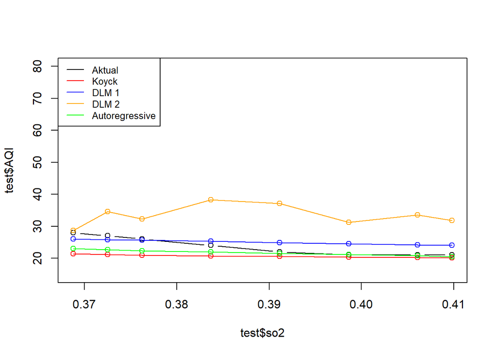

```r
par(mfrow=c(1,1))

plot(test$so2, test$AQI, type="b", col="black", ylim=c(15,80))

points(test$so2, fore.koyck$forecasts, col="red");   lines(test$so2, fore.koyck$forecasts, col="red")
points(test$so2, fore.dlm$forecasts, col="blue");    lines(test$so2, fore.dlm$forecasts, col="blue")
points(test$so2, fore.dlm2$forecasts, col="orange"); lines(test$so2, fore.dlm2$forecasts, col="orange")
points(test$so2, fore.ardl$forecasts, col="green");  lines(test$so2, fore.ardl$forecasts, col="green")

legend("topleft",
       c("Aktual", "Koyck","DLM 1","DLM 2", "Autoregressive"),
       lty=1, col=c("black","red","blue","orange","green"), cex=0.8)
```

Berdasarkan plot perbandingan, model DLM 2 sangat berbeda dibandingkan dengan model aktual. sementara model Koyck, DLM 1, dan Autoregresive hampir konstan pada satu nilai. Kesimpulannya, tidak ada model yang memiliki tren yang sama dengan nilai aktual. Namun, model Koyck, DLM 1, dan Autoregresive cukup baik dalam mendekati nilai aktual. Sedangkan DLM 2 cenderung overestimate dan tidak cocok untuk data tersebut.